# scone Vignette

Nick Borcherding

3/16/2020

## Loading Libraries

```r
suppressMessages(library(scone))
suppressMessages(library(Seurat))
```

## Loading Processed Single-Cell Data

For the demonstration of scone, the package includes 1,988 malignant and normal peripheral blood T cells from a Sezary syndrome patient. To read more about the data itself, please see the accompanying reference. The data has been re-integrated using Seurat v3.1.4 and randomly sampled to produce a smaller Seurat object for the purposes of this demonstration.

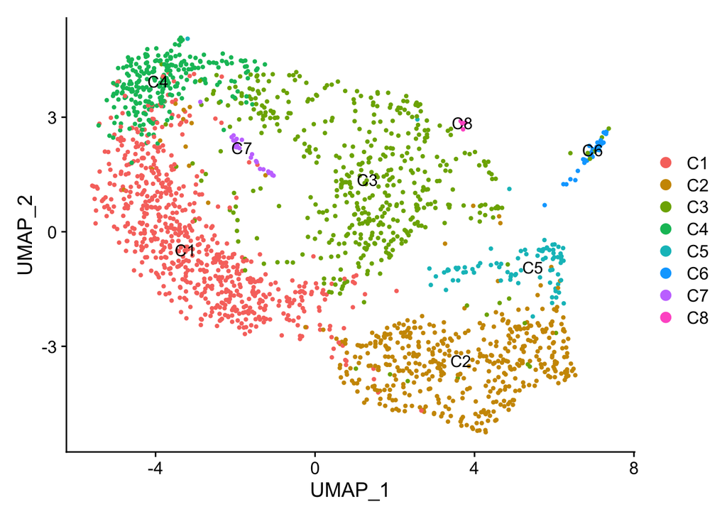

```r
data("seurat")
DimPlot(object = seurat, reduction = 'umap', label = T)
```

As you can see, we have 8 principal clusters, which are labeled C1-8. If interested we can also visualize the type of cells in the clusters by using the *type* parameter, where *T* are malignant T cells and *N* are nonmalignant T cells.

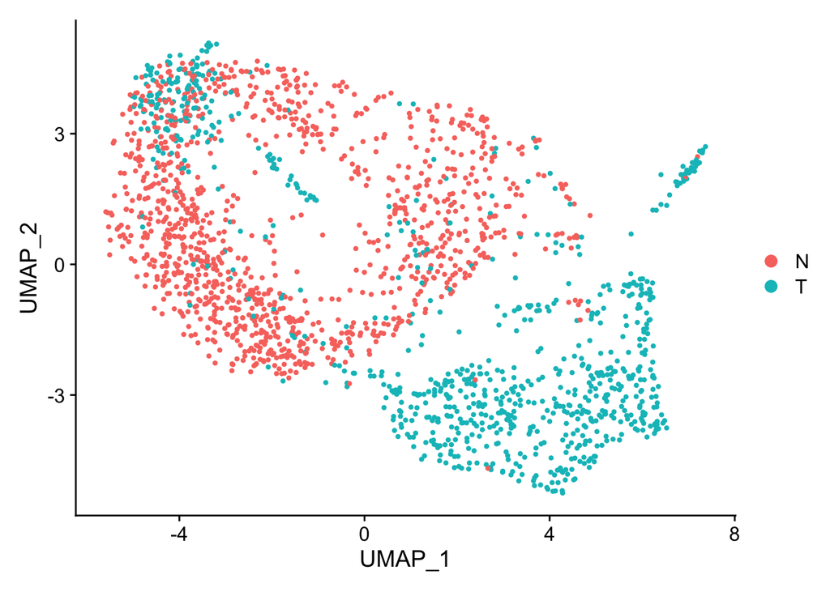

```r
DimPlot(object = seurat, reduction = 'umap', group.by = "Type")
```

## Getting Gene Sets

The first step in the process of performing gene set enrichment analysis is identifying the gene sets we would like to use. The function `GeteGeneSets` allows users to isolate a whole or multiple libraries from the [Molecular Signature Datbase](https://www.gsea-msigdb.org/gsea/msigdb/search.jsp) by setting the parameter *library* equal to library/libraries of interest. For multiple libraries, just set library = c(“Library1”, “Library2”, etc). Individual pathways/gene sets can be isolated from the libraries selected, by setting *pathways* = the name(s) of the gene sets of interest.

```r
GS <- GetGeneSets(library = "Hallmark")
```

If a user would like to expand beyond the GSEA Molecular Signature Database for pathway analysis, the enrichment function `EnrichIt()` uses a GeneSetCollection from the GSEABase R package. An [excellent vignette](https://www.bioconductor.org/packages/devel/bioc/vignettes/GSEABase/inst/doc/GSEABase.pdf) exists on how to create GeneSetCollections to be used in the enrichment analysis.

## Enrichment

The next step is performing the enrichment on the RNA count data. The function `EnrichIt()` can handle either a matrix of raw count data or will pull that data directly from a Seurat object. The *signature* parameter in the function is the GeneSetCollection, either generated from `GetGeneSet()` or from the user. The enrichment scores will be calculated across all individual cells and *groups* is the n size to break the enrichment by while the *cores* is the number of cores to perform in parallel during the enrichment calculation too.

*Important Note:* This is computationally intensive and is highly dependent on the number of cells and the number of gene sets included.

```r
ES <- EnrichIt(counts = seurat, signatures = GS, groups=1000, cores= 2)
```

```
## [1] "Using sets of 1000 cells. Running 2 times."
## Estimating ssGSEA scores for 50 gene sets.
##
##
## Estimating ssGSEA scores for 50 gene sets.
##
##
```

We can use the meta data from the Seurat object to attach additional information later that may be helpful when graphing the results. The function `LetsGetMeta` uses the Seurat object (*seurat*) and the output of `EnrichIt` (*enriched*) to attach the column headers **orig.ident** and **active.ident** from the Seurat Object. Additional columns to add can be selected using the *columns* parameter, for instance **Type** will give us whether the cell is malignant or normal.

```r
ES2 <- LetsGetMeta(seurat=seurat, enriched = ES, columns = "Type")
```

## Visualizations

#### 1. The Heatmap

A simple way to approach visualizations for enrichment results is the heatmap, especially if you are using a number of gene sets or libraries. The function `FeelTheHeat()` will create an easy-to-use heatmap.

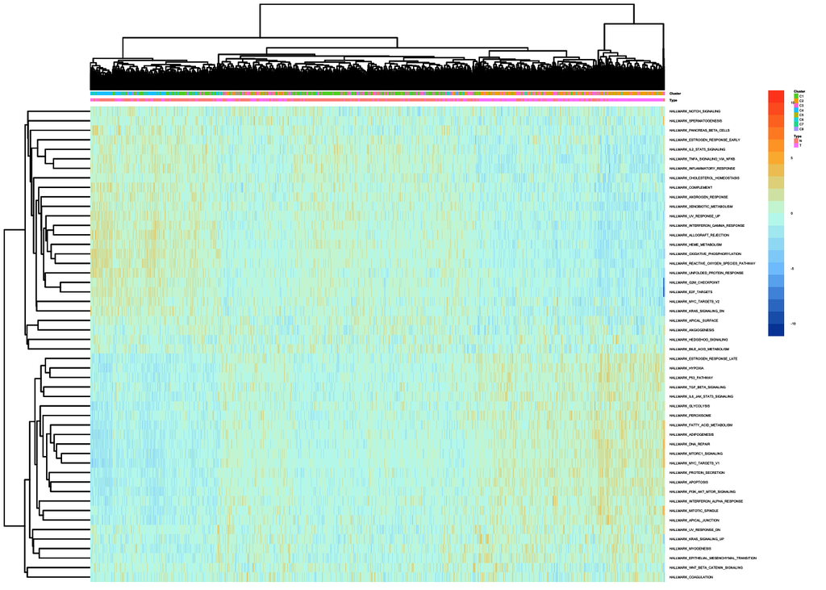

```r
annotation <- c("Cluster", "Type")
FeelTheHeat(enriched = ES2, annotation = annotation, cluster.row = T, cluster.column = T, scale = T)
```

A user can also produce a heatmap with select gene sets by using the *pathways* parameter in the `FeelTheHeat()` function. For example, we can isolated gene sets involved in apoptosis and DNA damage.

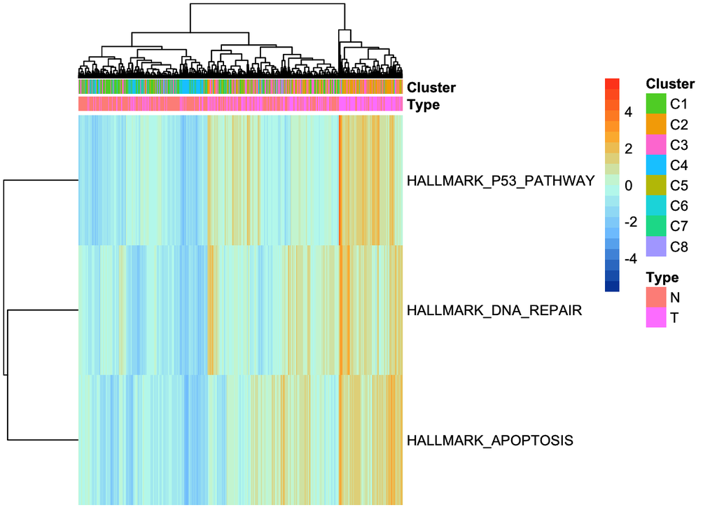

```r
FeelTheHeat(ES2, pathways = c("HALLMARK_APOPTOSIS", "HALLMARK_DNA_REPAIR", "HALLMARK_P53_PATHWAY"), annotation = annotation)
```

#### 2. The Violin Plot

Another way to visualize a subset of gene set enrichment would be to graph the distribution of enrichment using a violin plot in the `SmallestViolin` function.

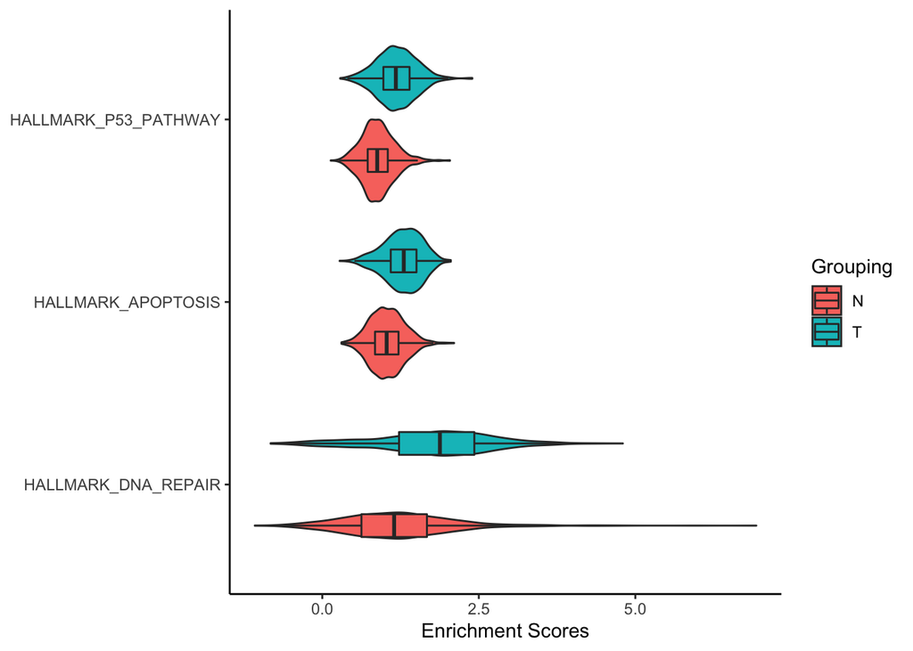

```r
SmallestViolin(ES2, groups="Type", pathways = c("HALLMARK_APOPTOSIS", "HALLMARK_DNA_REPAIR", "HALLMARK_P53_PATHWAY"))
```

We can also compare the distribution of enrichment scores of 2 distinct gene sets across all single cells using the `CompareEnrichment()` function. Here, we take the results of `EnrichIt()` and call specific gene sets to the *x.axis* and *y.axis* to produce a density plot. We can also add contours to the plot, by selecting *contours* = T.

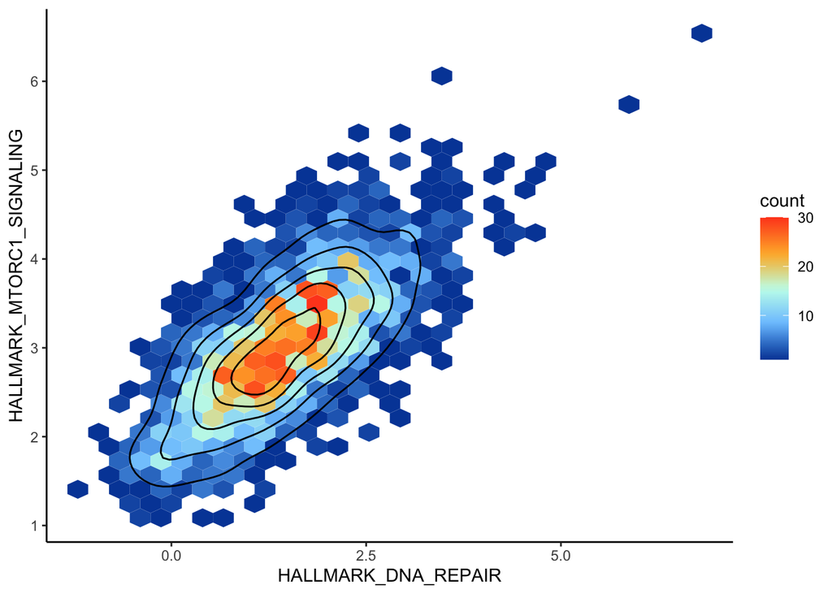

```r
CompareEnrichment(ES2, x.axis = "HALLMARK_DNA_REPAIR", y.axis = "HALLMARK_MTORC1_SIGNALING", contours = T)
```

We can also separate the graph using the *facet* parameter, allowing for the direct comparison of categorical variables like **Type** or **Cluster**

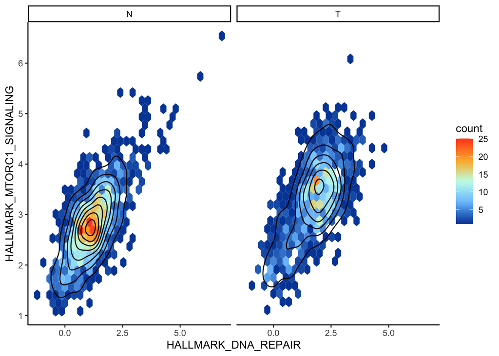

```r
CompareEnrichment(ES2, x.axis = "HALLMARK_DNA_REPAIR", y.axis = "HALLMARK_MTORC1_SIGNALING", contours = T, facet = "Type")
```

## Expanded Analysis

One frustration of Gene Set Enrichment is trying to make sense of the values. In order to move away from just selecting pathways that may be of interest, scone offers the ability to `PerformPCA()` on the enrichment scores. Like the other functions, we will need the output of `EnrichIt` (*enriched*) and the *groups* to include for later graphing.

```r
PCA <- PerformPCA(enriched=ES2, groups = c("Type", "Cluster"))
```

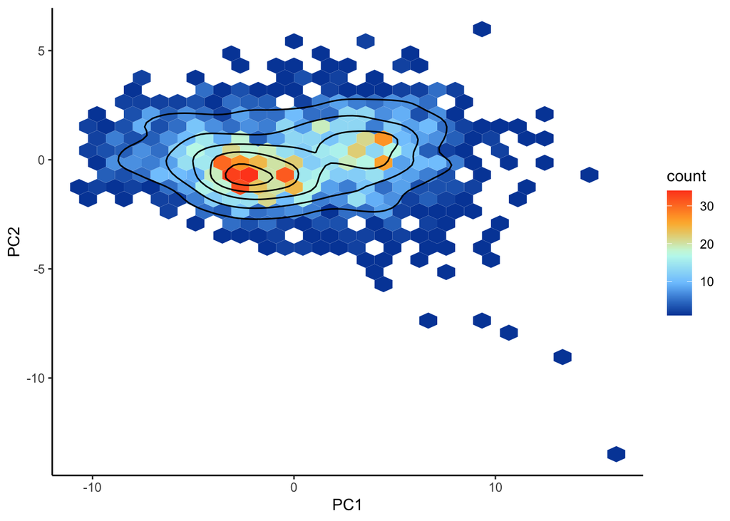

```r
BlobPlot(PCA, PCx="PC1", PCy="PC2", contours = T)
```

Like `CompareEnrichment()`, we can also look at the `BlobPlot` output separated by categorical factors using the *facet* parameter, for example using the cluster assignment.

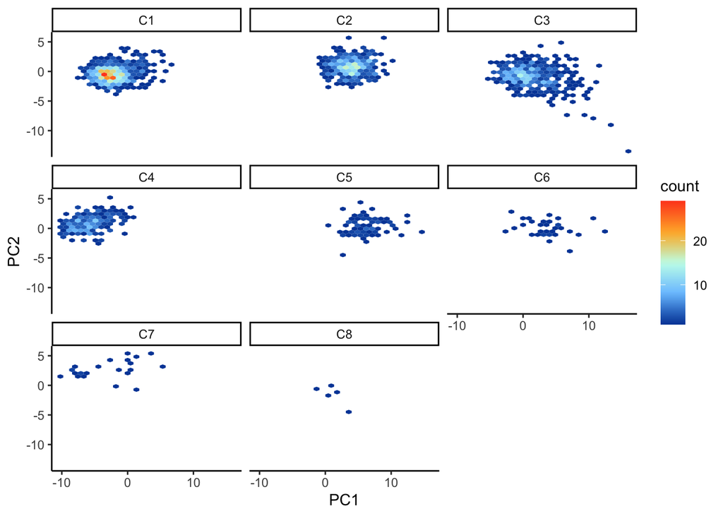

```r
BlobPlot(PCA, PCx="PC1", PCy="PC2", contours = F, facet = "Cluster")
```

We can more closely examine the construction of the PCA by looking at the contribution of each gene set to the respective principal component using `masterBlob` with the same input as above with the `Blobplot()`. We can also control the gene sets graphed by selecting more or less than 10 for *top.contribution*.

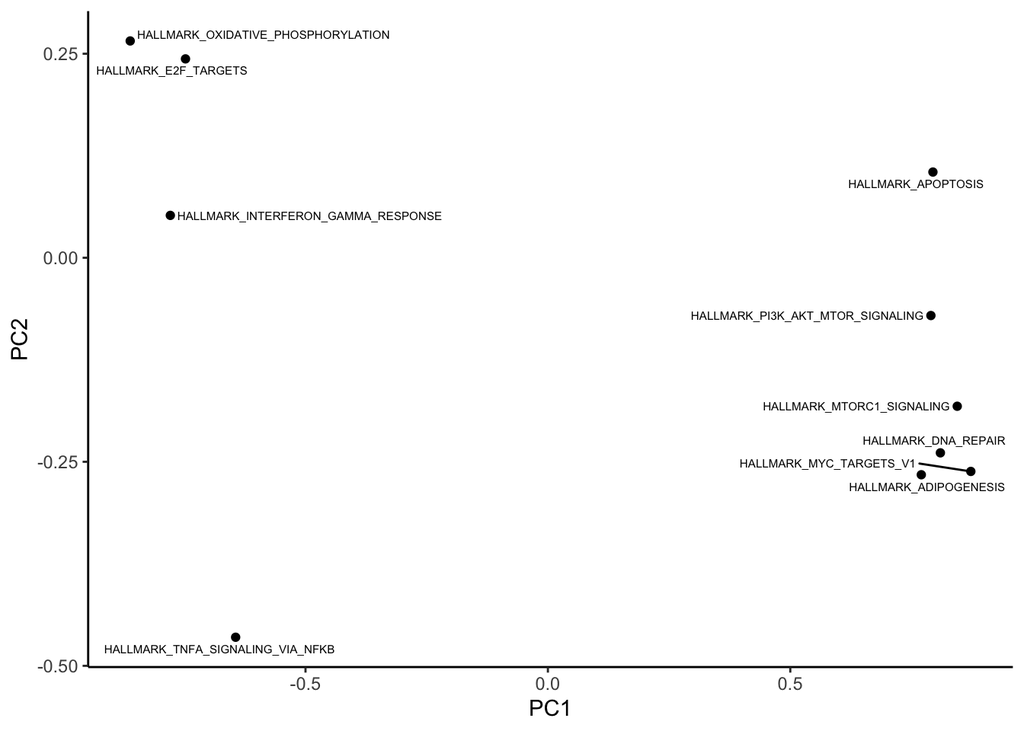

```r
masterBlob(ES2, PCx="PC1", PCy="PC2", top.contribution = 10)
```

## Conclusions

Hopefully this is helpful for analysis of single-cell datasets. Although not extensive, in terms of a fully-functional toolkit, scone functions focus on issues that PIs frequently request, making sense of data If you have any questions, comments or suggestions, feel free to visit the github repository or email me.